# CSDE 502 Winter 2021, Assignment 8

Lizzy Pelletier

```r
library(captioner)
library(haven)
library(tidyverse)
```

```r
library(knitr)

figure_nums <- captioner(prefix = "Figure")
table_nums <- captioner(prefix = "Table")
```

*Explanation*: This assignment is intended to give you more practice delving into the Add Health data set and in manipulating additional variables.

*Instructions*:

1. Make sure your Rmd file has no local file system dependencies (i.e., anyone should be able to recreate the output HTML using only the Rmd source file).
2. Make a copy of this Rmd file and add answers below each question. The code that generated the answers should be included, as well as the complete source code for the document.
3. Change the YAML header above to identify yourself and include contact information.
4. For any tables or figures, include captions and cross-references and any other document automation methods as necessary.
5. Make sure your output HTML file looks appealing to the reader.
6. Upload the final Rmd to your github repository.
7. Download [`assn_id.txt`](http://staff.washington.edu/phurvitz/csde502_winter_2021/assignments/assn_id.txt) and include the URL to your Rmd file on github.com.
8. Create a zip file from your copy of `assn_id.txt` and upload the zip file to the Canvas site for Assignment 9. *The zip file should contain only the text file. Do not include any additional files in the zip file–everything should be able to run from the file you uploaded to github.com. Please use zip format and not 7z or any other compression/archive format.*

# 1

**Using the full household roster (you’ll need to go back the full raw data source, [21600-0001-Data.dta](http://staff.washington.edu/phurvitz/csde502_winter_2021/data/21600-0001-Data.dta.zip)), create the following variables for each respondent. Document any decisions that you make regarding missing values, definitions, etc. in your narrative as well as in the R code. Include a frequency tabulation and a histogram of each result.**

```r
# download file from URL; unzip and load
tmp <- Sys.getenv("TMPDIR")

download.file(
  url="http://staff.washington.edu/phurvitz/csde502_winter_2021/data/21600-0001-Data.dta.zip",
  destfile= file.path(tmp, "21600-0001-Data.dta.zip", fsep=""))

ah <- read_dta(unz(file.path(tmp, "21600-0001-Data.dta.zip", fsep=""), filename="21600-0001-Data.dta"))
```

## 1.1

**Total number in household**

I used the first question for each household member to count the number in the household. For each question, if participants marked a “7” for legitimate skip (they didn’t have another member of their household), I did not add to the count. If participants did not mark 7, I added to the count of household members until they marked 7.

```r
hhmem <- ah %>%
    select(AID, H1HR2A, H1HR2B, H1HR2C, H1HR2D, H1HR2E,
           H1HR2F, H1HR2G, H1HR2H, H1HR2I, H1HR2J,
           H1HR2K, H1HR2L, H1HR2M, H1HR2N, H1HR2O,
           H1HR2P, H1HR2Q, H1HR2R, H1HR2S, H1HR2T)

hhmem$counter <- 0
for (i in 2:21) {
    hhmem <- hhmem %>%
        mutate(counter = ifelse(hhmem[,i]==7, counter, counter+1))
}
hhsize <- data.frame(t(table(hhmem$counter))) %>%
    select(Var2, Freq) %>%
    rename(HHSize=Var2, Freq=Freq)

kable(hhsize)
```

| HHSize | Freq |
| --- | --- |
| 0 | 14 |
| 1 | 381 |
| 2 | 1283 |
| 3 | 2128 |
| 4 | 1441 |
| 5 | 689 |
| 6 | 301 |
| 7 | 144 |
| 8 | 60 |
| 9 | 22 |
| 10 | 15 |
| 11 | 9 |
| 12 | 9 |
| 13 | 1 |
| 14 | 1 |
| 16 | 1 |
| 20 | 5 |

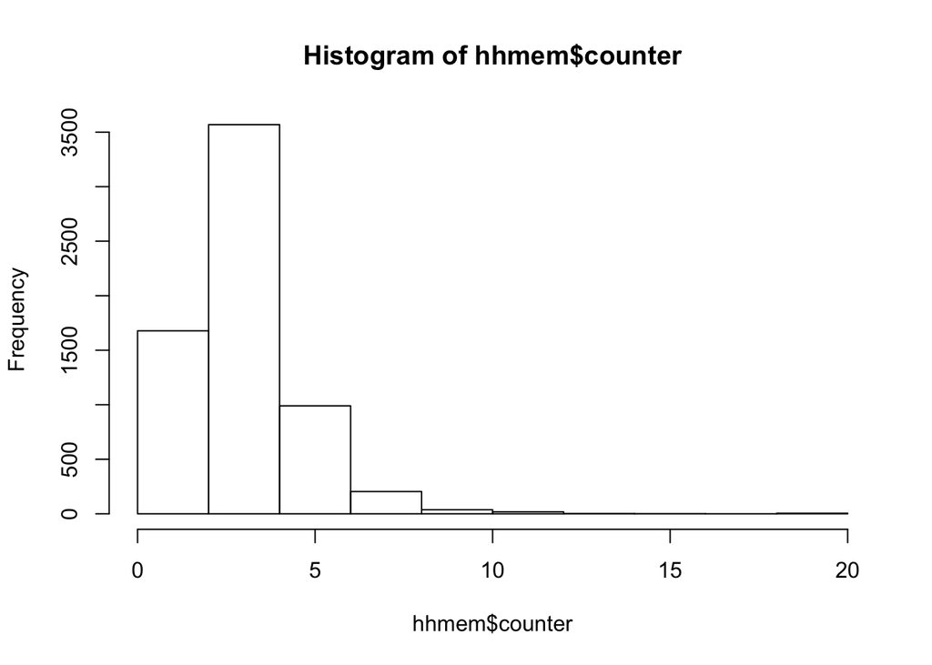

```r
hist(hhmem$counter)
```

## 1.2

**Number of sisters**

Each time a participant listed a household member as being a sister (e.g., H1HR3A==8), I increased their count of sisters by 1.

```r
sisters <- ah %>%
    select(AID, H1HR3A, H1HR3B, H1HR3C, H1HR3D, H1HR3E,
           H1HR3F, H1HR3G, H1HR3H, H1HR3I, H1HR3J,
           H1HR3K, H1HR3L, H1HR3M, H1HR3N, H1HR3O,
           H1HR3P, H1HR3Q, H1HR3R, H1HR3S, H1HR3T)
sisters$counter <- 0
for (i in 2:21) {
    sisters <- sisters %>%
        mutate(counter = ifelse(sisters[,i]==8, counter+1, counter))
}
sis <- data.frame(t(table(sisters$counter))) %>%
    select(Var2, Freq) %>%
    rename(Sisters=Var2, Freq=Freq)

kable(sis)
```

| Sisters | Freq |
| --- | --- |
| 0 | 3355 |
| 1 | 2284 |
| 2 | 654 |
| 3 | 171 |
| 4 | 32 |
| 5 | 5 |
| 6 | 2 |
| 7 | 1 |

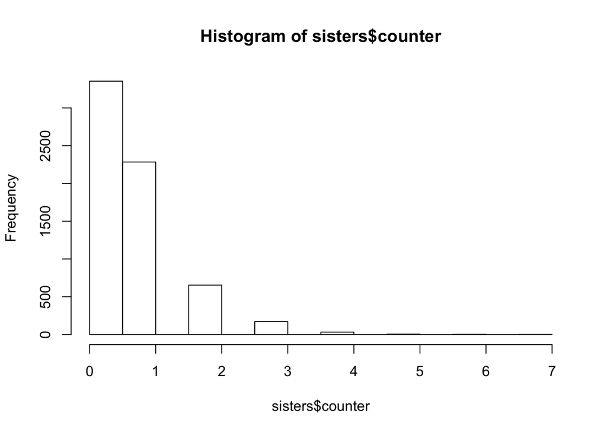

```r
hist(sisters$counter)
```

## 1.3

**Number of brothers**

Each time a participant listed a household member as being a brother (e.g., H1HR3A==5), I increased their count of sisters by 1.

```r
brothers <- ah %>%
    select(AID, H1HR3A, H1HR3B, H1HR3C, H1HR3D, H1HR3E,
           H1HR3F, H1HR3G, H1HR3H, H1HR3I, H1HR3J,
           H1HR3K, H1HR3L, H1HR3M, H1HR3N, H1HR3O,
           H1HR3P, H1HR3Q, H1HR3R, H1HR3S, H1HR3T)
brothers$counter <- 0
for (i in 2:21) {
    brothers <- brothers %>%
        mutate(counter = ifelse(brothers[,i]==5, counter+1, counter))
}
bro <- data.frame(t(table(brothers$counter))) %>%
    select(Var2, Freq) %>%
    rename(Brothers=Var2, Freq=Freq)

kable(bro)
```

| Brothers | Freq |
| --- | --- |
| 0 | 3181 |
| 1 | 2326 |
| 2 | 764 |
| 3 | 199 |
| 4 | 28 |
| 5 | 4 |
| 6 | 1 |
| 8 | 1 |

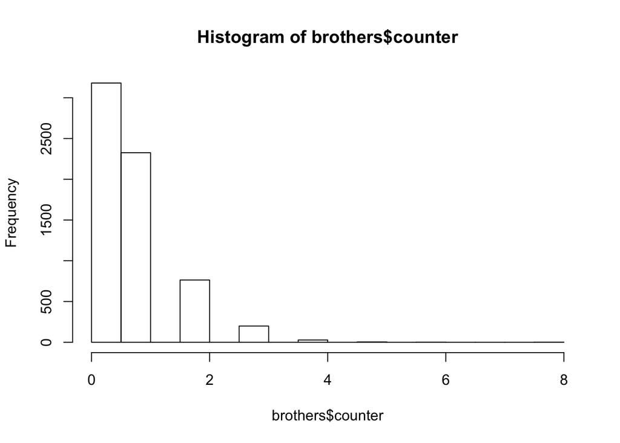

```r
hist(brothers$counter)
```

## **Total number of siblings**

I added the number of brothers to the number of sisters.

```r
sibs <- sisters$counter + brothers$counter
sib <- data.frame(t(table(sibs))) %>%
    select(sibs, Freq) %>%
    rename(Siblings=sibs, Freq=Freq)

kable(sib)
```

| Siblings | Freq |
| --- | --- |
| 0 | 1543 |
| 1 | 2499 |
| 2 | 1537 |
| 3 | 590 |
| 4 | 209 |
| 5 | 86 |
| 6 | 27 |
| 7 | 9 |
| 9 | 2 |
| 10 | 1 |
| 12 | 1 |

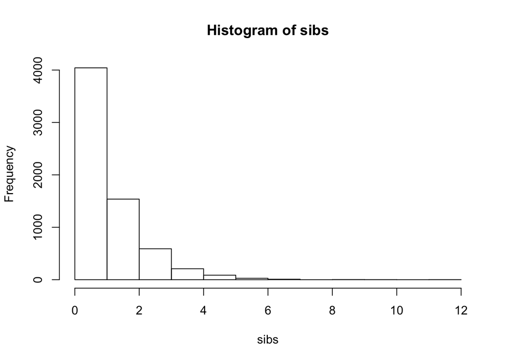

```r
hist(sibs)
```

# 2

**What proportion of students live with two biological parents? Include the analysis in your R code.**

```r
parents <- ah %>%
    select(AID, H1HR3A, H1HR3B, H1HR3C, H1HR3D, H1HR3E,
           H1HR3F, H1HR3G, H1HR3H, H1HR3I, H1HR3J,
           H1HR3K, H1HR3L, H1HR3M, H1HR3N, H1HR3O,
           H1HR3P, H1HR3Q, H1HR3R, H1HR3S, H1HR3T)
parents$biomom <- FALSE
parents$biodad <- FALSE
for (i in 2:21) {
    parents <- parents %>%
        mutate(biodad = ifelse(parents[,i]==11, TRUE, biodad)) %>%
        mutate(biomom = ifelse(parents[,i]==14, TRUE, biomom)) %>%
      mutate(bothparents = case_when(
        biodad==TRUE & biomom==TRUE ~ 1,
        biodad==FALSE | biomom==FALSE ~ 0
      ))

}

biopar <- data.frame(t(table(parents$bothparents))) %>%
  select(Var2, Freq) %>%
  rename(BothParents = Var2)
```

Share living with both parents = `mean(parents$bothparents)` = 0.64.

# 3

**Calculate the number of household members that are NOT biological mother, biological father, full brother or full sister. Create a contingency table and histogram for this variable.**

```r
rels <- ah %>%
    select(AID, H1HR3A, H1HR3B, H1HR3C, H1HR3D, H1HR3E,
           H1HR3F, H1HR3G, H1HR3H, H1HR3I, H1HR3J,
           H1HR3K, H1HR3L, H1HR3M, H1HR3N, H1HR3O,
           H1HR3P, H1HR3Q, H1HR3R, H1HR3S, H1HR3T)
rels$numothers <- 0
for (i in 2:21) {
    rels <- rels %>%
        mutate(numothers = ifelse(
          (parents[,i] != 8 & parents[,i] != 11 &
            parents[,i] != 5 & parents[,i] != 14 &
            parents[,i] != 96 & parents[,i] != 97 &
            parents[,i] != 98), numothers+1, numothers
        ))

}
otherrel <- data.frame(t(table(rels$numothers))) %>%
    select(Var2, Freq) %>%
    rename(OtherRelatives=Var2, Freq=Freq)

kable(otherrel)
```

| OtherRelatives | Freq |
| --- | --- |
| 0 | 4679 |
| 1 | 1103 |
| 2 | 391 |
| 3 | 154 |
| 4 | 89 |
| 5 | 45 |
| 6 | 22 |
| 7 | 9 |
| 8 | 5 |
| 9 | 3 |
| 10 | 1 |
| 11 | 2 |
| 12 | 1 |

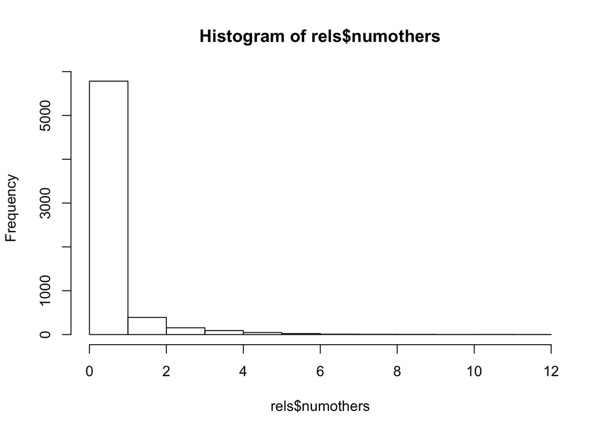

```r
hist(rels$numothers)
```

## 3.1 Source code

```r
cat(readLines(con = "csde502_2021_assignment09.Rmd"), sep = '\n')
```

````
---
title: "CSDE 502 Winter 2021, Assignment 8"
author: "[Lizzy Pelletier](mailto:epell@uw.edu)"
output:
    bookdown::html_document2:
        number_sections: true
        self_contained: true
        code_folding: hide
        toc: true
        toc_float:
            collapsed: true
            smooth_scroll: false
    pdf_document:
        number_sections: true
        toc: true
        fig_cap: yes
        keep_tex: yes
urlcolor: blue
---

```{r}
library(captioner)
library(haven)
library(tidyverse)
library(knitr)

figure_nums <- captioner(prefix = "Figure")
table_nums <- captioner(prefix = "Table")
```

___Explanation___:
This assignment is intended to give you more practice delving into the Add Health data set and in manipulating additional variables.

___Instructions___:

1. Make sure your Rmd file has no local file system dependencies (i.e., anyone should be able to recreate the output HTML using only the Rmd source file).
1. Make a copy of this Rmd file and add answers below each question. The code that generated the answers should be included, as well as the complete source code for the document.
1. Change the YAML header above to identify yourself and include contact information.
1. For any tables or figures, include captions and cross-references and any other document automation methods as necessary.
1. Make sure your output HTML file looks appealing to the reader.
````

[output cut: 160 more lines]

````

}
otherrel <- data.frame(t(table(rels$numothers))) %>%
    select(Var2, Freq) %>%
    rename(OtherRelatives=Var2, Freq=Freq)

kable(otherrel)
hist(rels$numothers)

```

## Source code
```{r comment=''}
cat(readLines(con = "csde502_2021_assignment09.Rmd"), sep = '\n')
```
````